# Assignment 1 - Python Basics

### Task 1

#### 1. Install Jupyter notebook and run the first program and share the screenshot of the output

```python
# First sample program in python

print("Hello World")
```

```
Hello World
```

Here is the first sample program and its screenshot

[figure not shown]

#### 2. Write a program which will find all such numbers which are divisible by 7 but are not a multiple of 5, between 2000 and 3200 (both included). The numbers obtained should be printed in a comma-separated sequence on a single line

##### Method 1 - Using print (end=",") and print("\b)

```python
for i in range (2000, 3201):
    if ( (i%7 == 0) and (i%5 != 0) ):
        print(i, end=",") # end="," to keep "," after every number
print("\b") # To remove "," after last output(backspace)
```

```
2002,2009,2016,2023,2037,2044,2051,2058,2072,2079,2086,2093,2107,2114,2121,2128,2142,2149,2156,2163,2177,2184,2191,2198,2212,2219,2226,2233,2247,2254,2261,2268,2282,2289,2296,2303,2317,2324,2331,2338,2352,2359,2366,2373,2387,2394,2401,2408,2422,2429,2436,2443,2457,2464,2471,2478,2492,2499,2506,2513,…
```

##### Method 2 - Using a list and string

```python
lst = [] # creating an empty list to store the data

for i in range (2000, 3201):
    if ( (i%7 == 0) and (i%5 != 0) ):
        lst.append(i) # appending values into list
print(str(lst)[1:-1]) # converting list into a string then removing [] and print
```

```
2002, 2009, 2016, 2023, 2037, 2044, 2051, 2058, 2072, 2079, 2086, 2093, 2107, 2114, 2121, 2128, 2142, 2149, 2156, 2163, 2177, 2184, 2191, 2198, 2212, 2219, 2226, 2233, 2247, 2254, 2261, 2268, 2282, 2289, 2296, 2303, 2317, 2324, 2331, 2338, 2352, 2359, 2366, 2373, 2387, 2394, 2401, 2408, 2422, 2429, …
```

#### 3. Write a Python program to accept the user's first and last name and then getting them printed in the the reverse order with a space between first name and last name.

```python
firstname = input("Please enter First Name: ")
lastname = input("Please enter Last Name: ")

print(firstname[::-1] + " " + lastname[::-1])
```

```
Please enter First Name: Ravi
Please enter Last Name: Kiran
ivaR nariK
```

#### 4. Write a Python program to find the volume of a sphere with diameter 12 cm.

Formula: V=4/3 *π* r 3

```python
# Accepting Diameter through user input
diameter = int(input("Please enter diameter of sphere in cm: "))
radius = diameter/2

# Calculating Volume of Sphere
pi = 22/7
r3 = radius**3
Volume = (4/3) * (pi * r3)
print("Diameter of Sphere is", diameter)
print("Radius of Sphere is", radius)
print("Volume of Sphere is", Volume)
```

```
Please enter diameter of sphere in cm: 12
Diameter of Sphere is 12
Radius of Sphere is 6.0
Volume of Sphere is 905.1428571428571
```

### Task 2

#### 1. Write a program which accepts a sequence of comma-separated numbers from console and generate a list.

```python
input_values = input("Please enter comma separated numbers: ")
lst = list(input_values.split(",")) # Splitting values at "," and converting into list
print(lst)
```

```
Please enter comma separated numbers: 1,2,3,4,5
['1', '2', '3', '4', '5']
```

#### 2. Create the below pattern using nested for loop in Python.

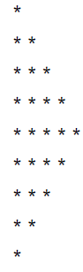

```python
for i in range(1,6):
    for j in range(i):
        print("*", end=" ")
    print()
for k in range (4,0,-1):
    for l in range(k):
        print("*", end=" ")
    print()
```

[output not shown]

#### 3. Write a Python program to reverse a word after accepting the input from the user.

Sample Output:  
Input word: AcadGild  
Output: dilGdacA

```python
input_string = input("Please enter a string to reverse: ")
print(input_string[::-1])
```

```
Please enter a string to reverse: gnirts a esrever ot margorp elpmas eht si sihT
This is the sample program to reverse a string
```

#### 4. Write a Python Program to print the given string in the format specified in the sample output

```python
"""WE, THE PEOPLE OF INDIA, having solemnly resolved to constitute India into a
SOVEREIGN, SOCIALIST, SECULAR, DEMOCRATIC REPUBLIC and to secure to all
its citizens

Sample Output:
WE, THE PEOPLE OF INDIA,
    having solemnly resolved to constitute India into a SOVEREIGN, !
        SOCIALIST, SECULAR, DEMOCRATIC REPUBLIC
        and to secure to all its citizens
"""
```

```
'WE, THE PEOPLE OF INDIA, having solemnly resolved to constitute India into a\nSOVEREIGN, SOCIALIST, SECULAR, DEMOCRATIC REPUBLIC and to secure to all\nits citizens\n\nSample Output:\nWE, THE PEOPLE OF INDIA,\n    having solemnly resolved to constitute India into a SOVEREIGN, !\n        SOCIALIST, S…
```

```python
string = "WE, THE PEOPLE OF INDIA,{}having solemnly resolved to constitute India into a SOVEREIGN,{}SOCIALIST, SECULAR, DEMOCRATIC REPUBLIC{}and to secure to all its citizens"
print(string.format('\n\t','!\n\t\t','\n\t\t'))
```

```
WE, THE PEOPLE OF INDIA,
	having solemnly resolved to constitute India into a SOVEREIGN,!
		SOCIALIST, SECULAR, DEMOCRATIC REPUBLIC
		and to secure to all its citizens
```

##### --------------------*** End of Assignment 1 ***-------------------